# Take-home exercise 2

ISSS608 Visual Analytics Take-home Exercise 2

Jiarui Cui www.linkedin.com/in/jiarui-cui-482232195 (School of Computing and Information Systems)https://scis.smu.edu.sg/  
2022-05-01

Distill is a publication format for scientific and technical writing, native to the web.

Learn more about using Distill for R Markdown at https://rstudio.github.io/distill.

# 1.Overview

This article aims to conduct a peer review of take-home exercise 01 for student [`Bomin Kim`](https://bominie.netlify.app/posts/2022-04-25-hw1/)，critic the submission in terms of clarity and aesthetics, and remake the original design by using the data visualisation principles learned in Lesson 1 and 2.

# 2.Getting Started

Before we get started, it is important for us to ensure that the required R packages have been installed. If yes, we will load the R packages.

If they have yet to be installed, we will install the R packages and load them onto R environment.

The chunk code on the right will do the trick.

```r
packages = c('tidyverse', 'plotly', 'readxl', 'knitr', 'dplyr', 'ggplot2',
             'grid', 'ggridges')

for(p in packages){
  if(!require(p, character.only = T)){
    install.packages(p)
  }
  library(p, character.only = T)
}
```

# 3.Importing & Preparig the Data

The code chunk below import *Participants.csv* and *FinancialJournal.csv* from the data folder into R by using [`read_csv()`](https://readr.tidyverse.org/reference/read_delim.html) of [**readr**](https://readr.tidyverse.org/) and save it as tibble dataframes respectively called *participants* and *FinancialJournal*.

```r
participants <- read_csv("data/participants.csv")
FinancialJournal <- read_csv("data/FinancialJournal.csv")
```

The student has also rebuilt the dataframe by simplifying the column names.

```r
participants <- participants %>%
  rename('householdsize'='householdSize',
         'havekids'='haveKids',
         'educationlevel'='educationLevel',
         'interestgroup'='interestGroup',
         'Happiness'='joviality')
```

```r
Wage <- FinancialJournal %>%
  filter(category == "Wage") %>%
  group_by(participantId) %>%
  select(participantId, amount) %>%
  summarise(wage = mean(amount))

write_rds(Wage,"data/wage.rds")

wage<-read_rds("data/wage.rds")
participants <- merge(x = participants, y = wage[ ,c("participantId","wage")],
by="participantId", all.x=TRUE)
```

Now, let’s look into the charts!

# 4.Peer Review

### 4.1 First glimp of age distribution

The original design planned to show the simple age distribution between participants having kids & not having kids.

While the histogram displayed above is not informative to show either a comparable proportion of having kids in each age group or a clear age distribution in separately with who have kids and not.

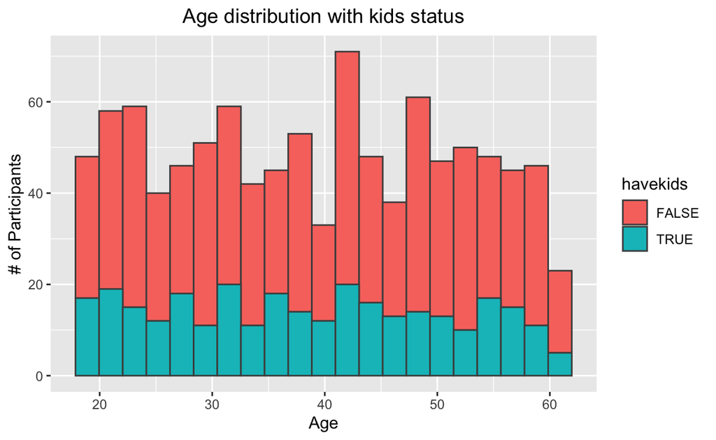

```r
ggplot(participants,aes(age,fill=havekids))+
  geom_histogram(bins=(max(participants$age)-min(participants$age))/2,color="grey30")+
  ggtitle("Age distribution with kids status")+
  xlab("Age")+ylab("# of Participants")+
  theme(plot.title = element_text(hjust = 0.5))
```

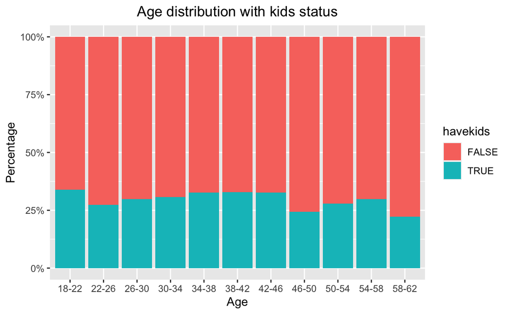

```r
participants$agegroup <- cut(participants$age,
                             breaks = c(17,22,26,30,34,38,42,46,50,54,58,63),
                             labels = c("18-22","22-26","26-30","30-34",
                                        "34-38","38-42","42-46","46-50",
                                        "50-54","54-58","58-62"))

ggplot(data = participants,aes(x= agegroup, fill = havekids)) +
  geom_bar(stat="count", position ="fill") +
  ggtitle("Age distribution with kids status")+
  theme(plot.title = element_text(hjust = 0.5))+
  xlab("Age")+ylab("# of Participants")+
  labs(x ="Age", y = "Percentage") +
  scale_y_continuous(labels = scales::percent)
```

I would also recommend to construct 2 histograms of age separately for residents having kids and not having kids.

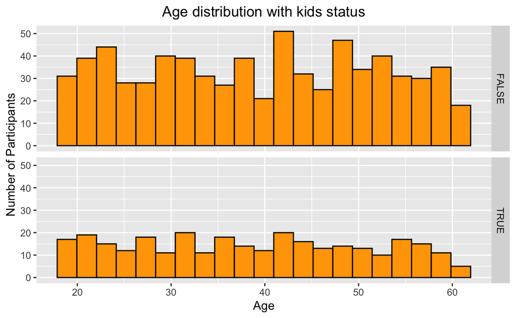

```r
ggplot(participants,aes(x = age))+
  geom_histogram(bins=(max(participants$age)-
                         min(participants$age))/2,
                 fill = 'orange',color = 'black')+
  facet_grid(havekids ~.)+
  ggtitle("Age distribution with kids status")+
  xlab("Age")+ylab("Number of Participants")+
  theme(plot.title = element_text(hjust = 0.5))
```

### 4.2 Pie chart of age groups

The original design planned to simply display the distribution of each age group. While piechart is not recommended since it contains not much information and taking up large space.

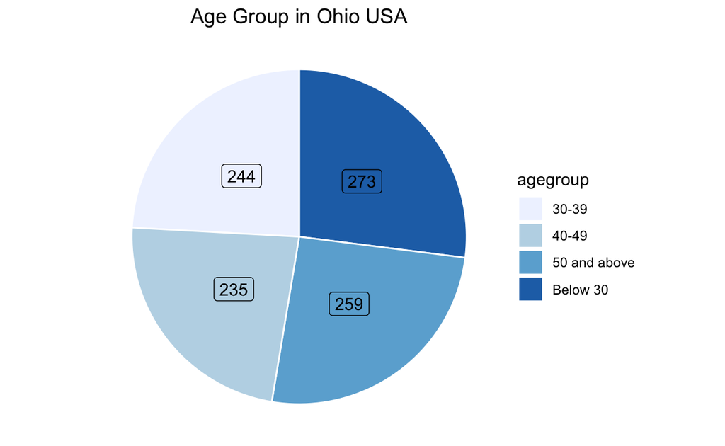

```r
participants<-participants%>%mutate(agegroup=case_when(age<30~"Below 30",
                                    age>=30 &age<40~"30-39",
                                    age>=40 &age<50~"40-49",
                                    age>=50 ~"50 and above"))

piedf <- participants %>% count(agegroup,sort=TRUE)

ggplot(piedf, aes(x="", y=n, fill=agegroup)) +
  geom_bar(stat="identity", width=1, color="white") +
  coord_polar("y", start=0) +
  theme_void() +
  geom_label(aes(label =n),
             position = position_stack(vjust = 0.5),
             show.legend = FALSE) +
  scale_fill_brewer() +
  ggtitle("Age Group in Ohio USA") +
  theme(plot.title = element_text(hjust = 0.5))
```

In this case, I would recommend using a simple barplot to show a more straightward view and sort the bars in descending proportion.

From the chart it is observed that residents in age wise are evenly distributed.

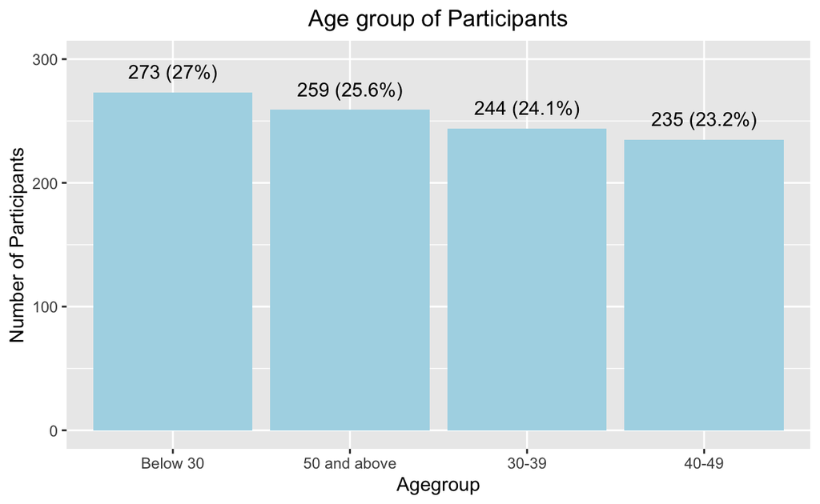

```r
participants<-participants%>%mutate(agegroup=case_when(age<30~"Below 30",
                                    age>=30 &age<40~"30-39",
                                    age>=40 &age<50~"40-49",
                                    age>=50 ~"50 and above"))

ggplot(data = participants,
       aes(x=reorder(agegroup, agegroup, function(x)-length(x)))) +
  geom_bar(fill = 'lightblue') +
  ylim(0,300) +
  geom_text(stat="count",
      aes(label=paste0(..count.., " (",
      round(..count../sum(..count..)*100,
            1), "%)")),
      vjust=-1) +
  xlab("Agegroup") +
  ylab("Number of Participants") +
  ggtitle("Age group of Participants")+
  theme(plot.title = element_text(hjust = 0.5))
```

### 4.3 Education level vs wage

The original design was to show income distribution of participants across different education level, so as to find the relationship between income and education. While the histogram below is not effectively revealing the pattern, especially for whose income over 400, since the number of participants is too small, differentiation between education level is hardly available.

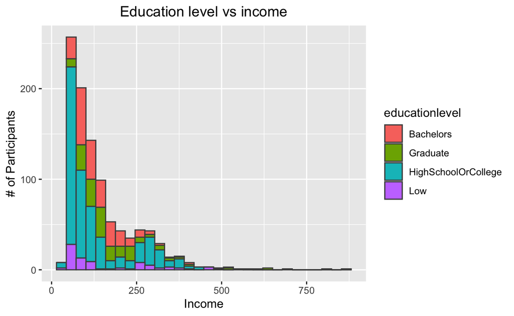

```r
ggplot(participants, aes(x=wage, fill=educationlevel))+
  geom_histogram(color="grey30")+
  xlab("Income")+ylab("# of Participants")+
  ggtitle("Education level vs income")+
  theme(plot.title = element_text(hjust = 0.5))
```

In this case, I would recommend adopting a boxplot which directly displays the distribution of income for each education level. I also sort the education level in an ascending order. From the plot we can observe that there is a remarable increase in income as the education level get higher.

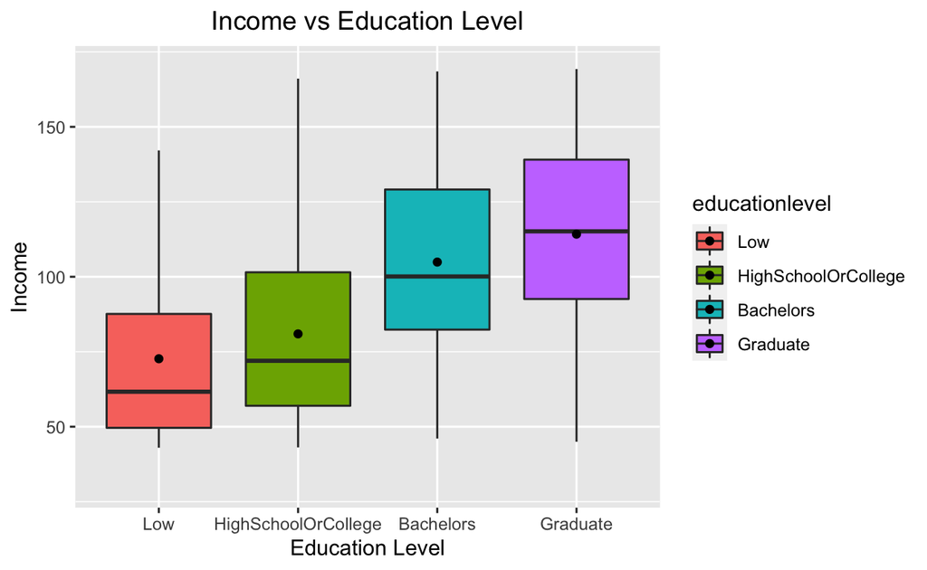

```r
participants$educationlevel <- factor(participants$educationlevel,
                                      levels = c("Low", "HighSchoolOrCollege",
                                                 "Bachelors", "Graduate"))
ggplot(participants,aes(y=wage,x=educationlevel,fill = educationlevel))+
  geom_boxplot()+
  ylim(30,170)+
  stat_summary(geom ="point")+
  xlab("Education Level")+ylab("Income")+
  ggtitle("Income vs Education Level")+
  theme(plot.title = element_text(hjust = 0.5))
```

### 4.4 Happiness vs income group

The original design clearly showed that the residents with a low income display the highest distribution of joviality.

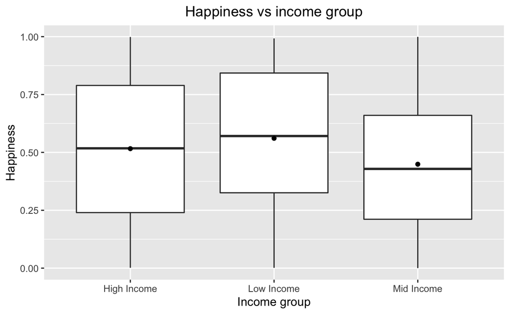

```r
participants<-participants%>%mutate(incomegroup=case_when(
  wage<quantile(participants$wage,probs=c(.25))~"Low Income",
  wage>=quantile(participants$wage,probs=c(.25))
  &wage<quantile(participants$wage,probs=c(.75))~"Mid Income",
  wage>=quantile(participants$wage,probs=c(.75)) ~"High Income"))

ggplot(participants,aes(y=Happiness,x=incomegroup))+
  geom_boxplot()+
  stat_summary(geom ="point")+
  xlab("Income group")+ylab("Happiness")+
  ggtitle("Happiness vs income group")+
  theme(plot.title = element_text(hjust = 0.5))
```

I experimented with the density plot, which gives a more detailed distribution. From the density plot we can observe that people with a mid income distribute the lowest joviality, people with a low income are the happiest, and the distribution of high income people is remarkably diverse in both direction.

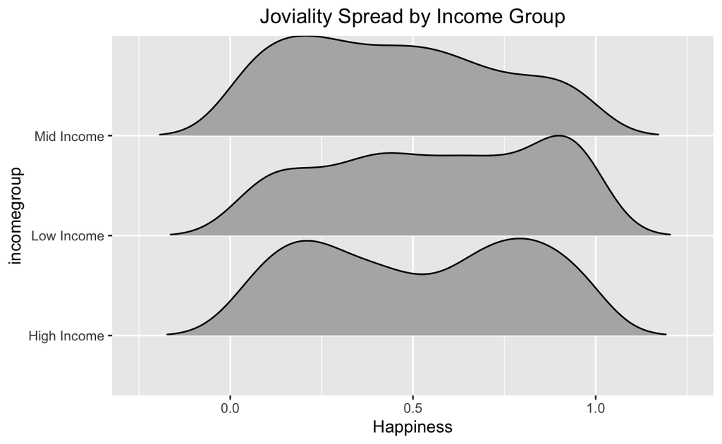

```r
ggplot(participants, aes(x = Happiness, y = incomegroup)) +
  geom_density_ridges(rel_min_height = 0.01,scale = 1) +
  ggtitle("Joviality Spread by Income Group")+
  theme(plot.title = element_text(hjust = 0.5))
```